# Hw8SDS

Allison Nguyen

2025-04-14

eid: ann2464

github: https://github.com/05alli/SDSHw8

# **Problem 1: regression warm up**

1. The expected creatinine clearance rate is 113.72 ml/min for a 55 year old. I calculated this by using a linear regression model,using the equation, B(0) + B(1) * age, to fit a linear regression model.
2. The creatinie clearance rate decreases by 0.62 ml/min. I calculated this by finding the slope coefficent for the linear regression model.
3. The 40 year olds are healthier than the 60 year olds for their age. I determined this by comparing the results of the 40 and 60 year olds which was found by subtracting the corresponding actual and expected values. 40 years old had a higher result meaning that they have better kidneys for their age.

# **Problem 2: Modeling disease growth**

1. Italy has a 95% confidence interval of 0.159 - 0.208 for estimated growth rate and a 95% confidence interval of 3.3 - 4.3 days for estimated doubling time.
2. Spain has a 95% confidence interval of 0.236 - 0.319 for estimated growth rate and a 95% confidence interval of 2.2 - 2.9 days for estimated doubling time.

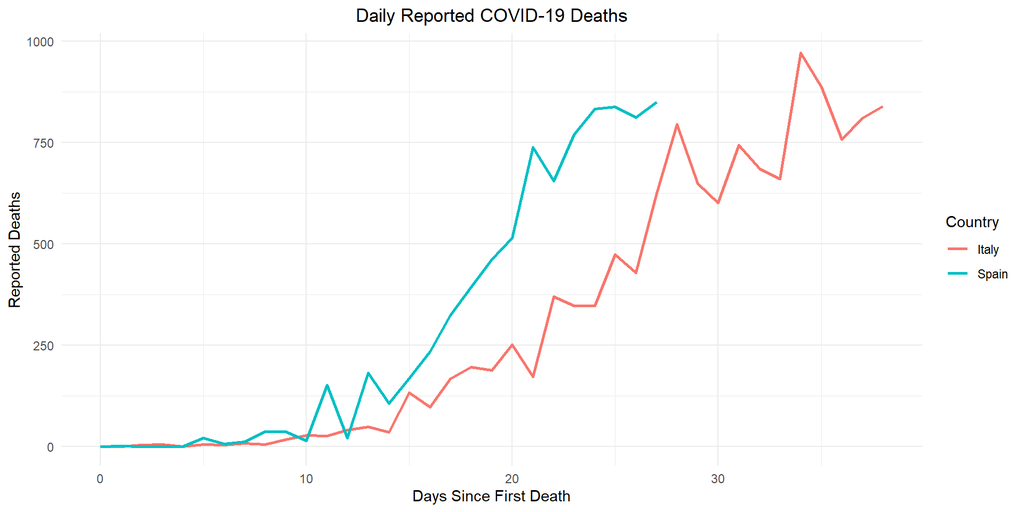

# **Problem 3: price elasticity of demand**

```
##                 2.5%     97.5%
## percentile -1.762224 -1.454805
```

I used the power-law model Q = K x P^B and took the logarithm of both sides to turn it into a straight-line relationship. I ran 1,000 Monte Carlo simulations to estimate the slope of the line, which represents price elasticity. The results show that elasticity is between -1.76 and -1.45 with 95% confidence, meaning demand for milk is elastic.